# Serology and PCR: summary-measure dot plots and Spearman correlations

Author

Nikolina Walas (nikolina.walas@ucsf.edu)

Published

October 13, 2026

Modified

October 7, 2026

## File overview

This file generates the pathogen x community-type dot-plot correlations.

Four comparisons are produced:

- **(A) SCR vs. PCR prevalence (pooled).** Giardia excluded from the Spearman ρ shown on the plot; Giardia points are still plotted, and the plot is annotated to say so. The Giardia-included ρ is computed and printed separately (not plotted). Used as the first (leftmost) panel of the combined figure below.
- **(B) SCR vs. PCR Kaplan-Meier cumulative incidence at 24 months.** Same Giardia handling as (A). Used as the second panel of the combined figure below. Its confidence interval now uses the same matched-sample bootstrap as A, C, and D (see below), rather than the row-level bootstrap `10-ecomid_dotplot_correlations.qmd` uses for this panel.
- **(C) SCR vs. seroprevalence (pooled).** Giardia included in ρ. Used as the third (rightmost) panel of the combined figure below.
- **(D) SCR vs. seroreversion rate (SRR).** Giardia included in ρ. Standalone only – not part of the combined figure below – but additionally exported as a saved ggplot object (`output/dotplot_scr_vs_srr.rds`) so it can be read into a separate R file for a supplemental figure there.

A, B, C, and D use a matched-sample bootstrap (resample 369 children with replacement, recompute pathogen-level summaries, take Spearman ρ across pathogens). D resamples from the union of `sero_conv` and `sero_rev`.

B resamples children and refitting a Kaplan-Meier curve on each replicate. The output file used is generated in `ecomid_cumulative_incidence_data.qmd` (exported as `ecomid_km_intervals_pcr_by_community.rds`) and just resampled by `childid` here, the same way A/C/D already resample `sero_conv`/ `pcr_all`. Only the `survfit()` refit itself runs inside the loop, and reading cumulative incidence at 24 months via `summary(fit, times = 24, extend = TRUE)` (instead of `broom::tidy()` + the `km_at_rounds()` forward-fill grid used elsewhere in this workflow) keeps each replicate’s per-pathogen extraction lean.

A combined 3-panel figure (single row) is exported. Its three panels are document panels A, B, and C, left to right, in that order – the combined figure’s panel order matches the document’s panel order exactly, so no separate composite lettering is needed. D (SCR vs. SRR) is not part of the combined figure; it remains standalone, and is additionally exported on its own as a saved ggplot object (see its bullet above).

### Load packages

```r
library(here)
source(here("R", "0-config.R"))
library(survival)
```

### Read in files

```r
# --- Community-level, pre-computed summary tables (population-level; same
#     source as 9-ecomid_sero_pcr_summary.qmd). "Borbon" is relabeled to the
#     accented "Borbón" immediately on read-in, to match comm_n_lookup and
#     the plot legend labels below -- without this, Borbón rows would fail
#     to match comm_n_lookup and silently drop out of the size legend. ---
sero_inc_type <- readRDS(here("output/ecomid_pathogen_comm_sero_inc_3_levels.rds")) %>%
  filter(pathogen != "Strongyloides" & pathogen != "T. solium") %>%
  mutate(community_type2 = ifelse(community_type2 == "Borbon", "Borbón", community_type2))
sero_inc_type$community_type2 <- factor(sero_inc_type$community_type2, levels = c("Esmeraldas", "Borbón", "Rural"))

sero_prev_type <- readRDS(here("output/ecomid_sero_prev_rates_3_levels.rds")) %>%
  mutate(community_type2 = ifelse(community_type2 == "Borbon", "Borbón", community_type2))
sero_prev_type$community_type2 <- factor(sero_prev_type$community_type2, levels = c("Esmeraldas", "Borbón", "Rural"))

pcr_prev_type <- readRDS(here("output/ecomid_pcr_prev_by_community_3_levels.rds")) %>%
  mutate(community_type2 = ifelse(community_type2 == "Borbon", "Borbón", community_type2))
pcr_prev_type$community_type2 <- factor(pcr_prev_type$community_type2, levels = c("Esmeraldas", "Borbón", "Rural"))

sero_rev_type <- readRDS(here("output/ecomid_pathogen_comm_sero_rev_3_levels.rds")) %>%
  filter(pathogen != "Strongyloides" & pathogen != "T. solium") %>%
  mutate(community_type2 = ifelse(community_type2 == "Borbon", "Borbón", community_type2))
sero_rev_type$community_type2 <- factor(sero_rev_type$community_type2, levels = c("Esmeraldas", "Borbón", "Rural"))

# --- Individual-level data, needed for the matched-sample bootstrap (A, C, D) ---
# "Borbon" relabeled to accented "Borbón" here too, for the same reason as
# pcr_all/sero_all below -- confirmed against the real data that sero_conv
# and sero_rev carry the raw unaccented "Borbon". Without this, every join
# against pcr_all/sero_all by community_type (comparisons A and C) would
# silently drop all Borbón rows from those bootstraps.
sero_conv <- readRDS(here("output/ecomid_sero_conv_tbl.rds")) %>%
  filter(pathogen != "Strongyloides" & pathogen != "T. solium") %>%
  mutate(community_type = as.character(community_type),
         community_type = ifelse(community_type == "Borbon", "Borbón", community_type))

sero_rev <- readRDS(here("output/ecomid_sero_rev_tbl.rds")) %>%
  filter(pathogen != "Strongyloides" & pathogen != "T. solium") %>%
  mutate(community_type = as.character(community_type),
         community_type = ifelse(community_type == "Borbon", "Borbón", community_type))

pcr_all <- readRDS(here("data","ecomid_pcr_analysis_data_2026-10-07.rds"))
pcr_all$community_type <- as.character(pcr_all$community_type)
pcr_all <- pcr_all %>% mutate(community_type = ifelse(str_detect(community_type, "Rural"), "Rural", community_type))
pcr_all <- pcr_all %>% mutate(community_type = ifelse(community_type == "Borbon", "Borbón", community_type))
pcr_all$community_type <- factor(pcr_all$community_type, levels = c("Esmeraldas", "Borbón", "Rural"))
pcr_all <- pcr_all %>% filter(pathogen %in% sero_conv$pathogen)

sero_all <- read_csv(here("..","..",
                      "data","serology","final","ecomid_serology_datasets",
                      "ecomid_sero_antigen_seropos_long_v02_20261007.csv")) %>%
  mutate(community_type = ifelse(str_detect(community_type, "Rural"), "Rural", community_type)) %>%
  mutate(community_type = ifelse(community_type == "Borbon", "Borbón", community_type)) %>%
  filter(antigen != "hlye") %>%
  filter(pathogen != "Strongyloides" & pathogen != "T. solium") %>%
  # collapse antigen > pathogen level: one row per child/timepoint/pathogen
  # seropositive if positive to any antigen (same definition as script 5)
  filter(!is.na(seropos)) %>%
  group_by(childid, timepoint, pathogen, community_type) %>%
  summarise(seropos=max(seropos), .groups = "drop")

# --- PCR KM cumulative incidence by community, every nominal round -- for B ---
# Exported by 7-ecomid_cumulative_incidence_data.qmd; relabeled to accented
# "Borbón" here for the same reason as the tables above.
km_pcr_by_comm_round <- readRDS(here("output/ecomid_km_pcr_by_community_round.rds")) %>%
  mutate(community_type2 = ifelse(community_type2 == "Borbon", "Borbón", community_type2)) %>% filter(time == 24) %>% filter(pathogen != "S. enterica")

# --- Per-child PCR Kaplan-Meier survival intervals, by community -- for B's
#     matched-sample bootstrap (section 2 below). Exported by
#     7-ecomid_cumulative_incidence_data.qmd as km_data_by_comm: one row per
#     child x pathogen x community_type2, giving that child's own
#     (tstart, tstop, event) interval. A child's interval doesn't depend on
#     which other children land in a given bootstrap resample, so it's built
#     once upstream in file 7 rather than rebuilt inside every one of B's
#     2000 replicates -- that per-child rebuild is what made an earlier
#     attempt at this too slow to run in practice. Relabeled to accented
#     "Borbón" and renamed to plain "community_type" to match sero_conv's
#     join key (same treatment as pcr_all above); S. enterica dropped here
#     too, matching km_pcr_by_comm_round's exclusion above, so B's
#     confidence interval is computed over the same pathogen set as its plot.
km_data_pcr_by_comm <- readRDS(here("output/ecomid_km_intervals_pcr_by_community.rds")) %>%
  mutate(community_type = ifelse(community_type2 == "Borbon", "Borbón", community_type2)) %>%
  filter(pathogen != "S. enterica") %>%
  select(childid, pathogen, community_type, tstart, tstop, event)

# Safety check: child ID pools for the matched-sample bootstraps (expect 369 each)
print("Safety check: length of childid used for match-sample bootstrap")
```

```
[1] "Safety check: length of childid used for match-sample bootstrap"
```

```r
c(
  A_scr_pcr  = length(union(sero_conv$childid, pcr_all$childid)),
  B_scr_km   = length(union(sero_conv$childid, km_data_pcr_by_comm$childid)),
  C_scr_prev = length(union(sero_conv$childid, sero_all$childid)),
  D_scr_srr  = length(union(sero_conv$childid, sero_rev$childid))
)
```

```
 A_scr_pcr   B_scr_km C_scr_prev  D_scr_srr
       369        369        369        369
```

# 1) Build pathogen x community-type comparison data-frames (A, C, D)

```r
d1 <- sero_prev_type %>%
  select(pathogen, community_type2, sero_prevalence, lower_ci, upper_ci, n_total) %>%
  filter(pathogen %in% pcr_prev_type$pathogen)

d1b <- sero_inc_type %>%
  select(pathogen, community_type2, ir_per_100) %>%
  filter(pathogen %in% pcr_prev_type$pathogen)

d2 <- pcr_prev_type %>%
  select(pathogen, community_type2, pcr_prevalence, lower_ci, upper_ci, n_total) %>%
  rename(lower_ci_pcr = lower_ci,
         upper_ci_pcr = upper_ci,
         n_total_pcr = n_total) %>%
  filter(pathogen %in% d1$pathogen)

pathogen_levels <- c("Campylobacter", "Cryptosporidium", "E. histolytica", "Giardia",
                      "LT-ETEC", "Norovirus GI", "Norovirus GII", "S. enterica", "Shigella/EIEC")

comm_n_lookup <- c(Esmeraldas = 84, "Borbón" = 108, Rural = 177)

# --- A) SCR (pooled) + PCR prevalence (pooled) ---
d3 <- left_join(d1b, d2, by = c("pathogen", "community_type2")) %>%
  mutate(n_children = comm_n_lookup[as.character(community_type2)])
d3$pathogen <- factor(d3$pathogen, levels = pathogen_levels)

# --- C) SCR + seroprevalence ---
d4 <- left_join(d1, d1b, by = c("pathogen", "community_type2")) %>%
  mutate(n_children = comm_n_lookup[as.character(community_type2)])
d4$pathogen <- factor(d4$pathogen, levels = pathogen_levels)

# --- D) SCR + SRR ---
d5 <- left_join(d1b %>% rename(scr_per_100 = ir_per_100),
                sero_rev_type %>% select(pathogen, community_type2, ir_per_100) %>%
                  rename(srr_per_100 = ir_per_100), by = c("pathogen", "community_type2")) %>%
  mutate(n_children = comm_n_lookup[as.character(community_type2)])
d5$pathogen <- factor(d5$pathogen, levels = pathogen_levels)
```

# 1b) PCR Kaplan-Meier cumulative incidence at 24 months (for B’s plot points)

Reuses `km_pcr_by_comm_round` (read in above), exported by `7-ecomid_cumulative_incidence_data.qmd` – no need to refit anything here. That export already applies the correct “hold the last KM step forward onto the nominal round grid” logic (including the EPS-rounding fix for baseline-positive event times), which is more careful than independently re-deriving a 24-month snapshot in this file would be.

**Data note (resolved):** `sero_conv`/`sero_rev` were confirmed to carry the raw unaccented “Borbon” (like every raw-data table in this file before relabeling), while `pcr_all`/`sero_all` are relabeled to accented “Borbón” on read-in. `sero_conv`/`sero_rev` are now relabeled the same way immediately after read-in (see above), so the matched-sample bootstraps for A and C correctly include all three community types when joining against `pcr_all`/`sero_all` by `community_type` (D’s inputs, `sero_conv` and `sero_rev`, are relabeled consistently with each other regardless).

```r
# --- B) SCR + PCR KM cumulative incidence, 24mo (plot + bootstrap data) ---
pcr_cuminc24_type <- km_pcr_by_comm_round %>%
  filter(time == 24) %>%
  select(pathogen, community_type2, pcr_cum_inc_24 = cum_inc)

d9 <- left_join(d1b, pcr_cuminc24_type, by = c("pathogen", "community_type2")) %>%
  mutate(n_children = comm_n_lookup[as.character(community_type2)])
d9$pathogen <- factor(d9$pathogen, levels = pathogen_levels)
```

# 2) Matched-sample bootstrap Spearman correlations (A, B, C, D)

```r
# Format to exactly 2 significant figures, keeping trailing zeros
sig2 <- function(x) formatC(x, digits = 2, format = "fg", flag = "#")

# Used by C: individual-level seroprevalence (IgG positivity), from
# sero_all.
summarize_serop <- function(df) {
  df %>%
    group_by(pathogen, community_type) %>%
    summarise(
      n_pos = sum(seropos, na.rm = TRUE),
      n_total = sum(!is.na(seropos)),
      prev = n_pos / n_total,
      .groups = "drop"
    )
}

# Used by A, B, C, and D: individual-level seroconversion rate (SCR), from
# sero_conv. All four of this file's matched-sample-bootstrap panels are
# anchored on SCR.
summarize_sero <- function(df) {
  df %>%
    group_by(pathogen, community_type) %>%
    summarise(
      total_seroconversions = sum(seroconversion, na.rm = TRUE),
      total_pt_years = sum(person_time_years, na.rm = TRUE),
      incidence_rate_per_year = total_seroconversions / total_pt_years,
      .groups = "drop"
    )
}

# Used by B: refits a per-pathogen, per-community Kaplan-Meier curve on
# whichever children a bootstrap replicate resampled (via km_data_pcr_by_comm,
# read in above), then reads off cumulative incidence at exactly 24 months.
# summary(..., times = 24, extend = TRUE) is used instead of broom::tidy() +
# the km_at_rounds() forward-fill grid used elsewhere in this workflow --
# both read the same fitted step function, but this skips formatting work
# broom::tidy() does that isn't needed for a single time point per stratum,
# which matters since this runs on every one of B's 2000 replicates.
# extend = TRUE reproduces km_at_rounds()'s forward-fill behavior for a
# pathogen whose last observed round falls before 24 months.
fit_km_cuminc24 <- function(df) {
  df %>%
    group_by(pathogen) %>%
    group_modify(~ {
      fit <- survfit(Surv(tstart, tstop, event) ~ community_type, data = .x)
      s <- summary(fit, times = 24, extend = TRUE)
      tibble(
        community_type = sub("^community_type=", "", as.character(s$strata)),
        cum_inc_24 = 1 - s$surv
      )
    }) %>%
    ungroup()
}
```

## A) SCR + PCR prevalence

```r
###############################################################
##### Matched-sample bootstrap: 369 children resampled with  ##
##### replacement from the union of the two datasets          #
###############################################################

## --- Giardia EXCLUDED (this is the version used ON the plot) ---
sero_conv2 <- sero_conv %>% filter(pathogen != "Giardia")
pcr2 <- pcr_all %>% filter(pathogen != "Giardia")

summarize_pcr <- function(df) {
  df %>%
    group_by(pathogen, community_type) %>%
    summarise(
      n_pos = sum(pcrpos, na.rm = TRUE),
      n_total = sum(!is.na(pcrpos)),
      pcr_prev = n_pos / n_total,
      .groups = "drop"
    )
}

compute_corr_boot_p1 <- function(sero_df, pcr_df) {
  all_ids <- union(sero_df$childid, pcr_df$childid)
  boot_ids <- sample(all_ids, size = length(all_ids), replace = TRUE)
  boot_tbl <- tibble(childid = boot_ids)

  sero_resampled <- boot_tbl %>% left_join(sero_df, by = "childid", relationship = "many-to-many")
  pcr_resampled  <- boot_tbl %>% left_join(pcr_df,  by = "childid", relationship = "many-to-many")

  sero_sum <- summarize_sero(sero_resampled)
  pcr_sum  <- summarize_pcr(pcr_resampled)

  merged <- inner_join(sero_sum, pcr_sum, by = c("pathogen", "community_type"))
  if (nrow(merged) < 3) return(NA_real_)
  cor(merged$incidence_rate_per_year, merged$pcr_prev, method = "spearman")
}

run_corr_ci_p1 <- function(sero_df, pcr_df) {
  set.seed(239)
  B <- 2000
  boot_r <- replicate(B, compute_corr_boot_p1(sero_df, pcr_df))

  merged_obs <- inner_join(summarize_sero(sero_df), summarize_pcr(pcr_df),
                            by = c("pathogen", "community_type"))
  observed_rho <- cor(merged_obs$incidence_rate_per_year, merged_obs$pcr_prev, method = "spearman")

  tibble(
    rs    = observed_rho,
    rs_lo = quantile(boot_r, 0.025, na.rm = TRUE),
    rs_hi = quantile(boot_r, 0.975, na.rm = TRUE)
  ) %>%
    mutate(final_rho = paste0(sig2(rs), " (", sig2(rs_lo), ", ", sig2(rs_hi), ")"))
}

# Giardia excluded -- used ON plot A
corr_ci_p1_excl <- run_corr_ci_p1(sero_conv2, pcr2)
corr_ci_p1_excl
```

```
# A tibble: 1 × 4
     rs rs_lo rs_hi final_rho
  <dbl> <dbl> <dbl> <chr>
1 0.807 0.702 0.858 0.81 (0.70, 0.86)
```

```r
# Giardia included -- reported separately, NOT plotted (supplement)
corr_ci_p1_incl <- run_corr_ci_p1(sero_conv, pcr_all)
corr_ci_p1_incl
```

```
# A tibble: 1 × 4
     rs rs_lo rs_hi final_rho
  <dbl> <dbl> <dbl> <chr>
1 0.629 0.506 0.672 0.63 (0.51, 0.67)
```

## B) SCR + PCR KM cumulative incidence, 24 months

Uses the same matched-sample bootstrap as A, C, and D (369 children resampled with replacement, pathogen-level summaries recomputed on each resample) rather than the row-level bootstrap over the ~27 aggregated pathogen x community points that `10-ecomid_dotplot_correlations.qmd` uses for this panel. The only structural difference from A/C/D is that the PCR side needs an actual model refit – `fit_km_cuminc24()`, defined above – instead of a simple resampled sum, since cumulative incidence at 24 months comes from a Kaplan-Meier curve rather than a raw proportion. `km_data_pcr_by_comm` (read in above) is what makes that refit affordable inside a 2000-replicate loop: it holds every child’s own survival interval, precomputed once in `7-ecomid_cumulative_incidence_data.qmd`, so each replicate below only resamples children and refits `survfit()` – it never rebuilds intervals from raw testing rounds, which is what made an earlier attempt at this too slow to run in practice.

Giardia handling matches (A): excluded from the ρ shown on the plot, with the all-pathogen ρ computed separately for reference. `sero_conv2` (Giardia excluded) is reused from (A)’s section above.

```r
km_data_pcr_by_comm2 <- km_data_pcr_by_comm %>% filter(pathogen != "Giardia")

compute_corr_boot_p4 <- function(sero_df, km_df) {
  all_ids <- union(sero_df$childid, km_df$childid)
  boot_ids <- sample(all_ids, size = length(all_ids), replace = TRUE)
  boot_tbl <- tibble(childid = boot_ids)

  scr_resampled <- boot_tbl %>% left_join(sero_df, by = "childid", relationship = "many-to-many")
  km_resampled  <- boot_tbl %>% left_join(km_df,  by = "childid", relationship = "many-to-many")

  scr_sum <- summarize_sero(scr_resampled)
  km_sum  <- fit_km_cuminc24(km_resampled)

  merged <- inner_join(scr_sum, km_sum, by = c("pathogen", "community_type"))
  if (nrow(merged) < 3) return(NA_real_)
  cor(merged$incidence_rate_per_year, merged$cum_inc_24, method = "spearman")
}

run_corr_ci_p4 <- function(sero_df, km_df) {
  set.seed(239)
  B <- 2000
  boot_r <- replicate(B, compute_corr_boot_p4(sero_df, km_df))

  merged_obs <- inner_join(summarize_sero(sero_df), fit_km_cuminc24(km_df),
                            by = c("pathogen", "community_type"))
  observed_rho <- cor(merged_obs$incidence_rate_per_year, merged_obs$cum_inc_24, method = "spearman")

  tibble(
    rs    = observed_rho,
    rs_lo = quantile(boot_r, 0.025, na.rm = TRUE),
    rs_hi = quantile(boot_r, 0.975, na.rm = TRUE)
  ) %>%
    mutate(final_rho = paste0(sig2(rs), " (", sig2(rs_lo), ", ", sig2(rs_hi), ")"))
}

# Giardia excluded -- used ON plot B
corr_ci_f <- run_corr_ci_p4(sero_conv2, km_data_pcr_by_comm2)
corr_ci_f
```

```
# A tibble: 1 × 4
     rs rs_lo rs_hi final_rho
  <dbl> <dbl> <dbl> <chr>
1 0.808 0.658 0.844 0.81 (0.66, 0.84)
```

```r
# Giardia included -- reported separately, NOT plotted (supplement)
corr_ci_f_incl <- run_corr_ci_p4(sero_conv, km_data_pcr_by_comm)
corr_ci_f_incl
```

```
# A tibble: 1 × 4
     rs rs_lo rs_hi final_rho
  <dbl> <dbl> <dbl> <chr>
1 0.657 0.485 0.677 0.66 (0.49, 0.68)
```

## C) SCR + seroprevalence

```r
sero_prev_indiv <- sero_all

# summarize_serop() and summarize_sero() are both defined above, in
# section 2's shared preamble.

compute_corr_boot_p2 <- function() {
  all_ids <- union(sero_conv$childid, sero_prev_indiv$childid)
  boot_ids <- sample(all_ids, size = length(all_ids), replace = TRUE)
  boot_tbl <- tibble(childid = boot_ids)

  scr_resampled   <- boot_tbl %>% left_join(sero_conv, by = "childid", relationship = "many-to-many")
  serop_resampled <- boot_tbl %>% left_join(sero_prev_indiv, by = "childid", relationship = "many-to-many")

  scr_sum   <- summarize_sero(scr_resampled)
  serop_sum <- summarize_serop(serop_resampled)

  merged <- inner_join(serop_sum, scr_sum, by = c("pathogen", "community_type"))
  if (nrow(merged) < 3) return(NA_real_)
  cor(merged$incidence_rate_per_year, merged$prev, method = "spearman")
}

set.seed(239)
boot_r <- replicate(2000, compute_corr_boot_p2())

merged_obs <- inner_join(summarize_sero(sero_conv), summarize_serop(sero_prev_indiv),
                          by = c("pathogen", "community_type"))
observed_rho <- cor(merged_obs$incidence_rate_per_year, merged_obs$prev, method = "spearman")

corr_ci_p2 <- tibble(
  rs    = observed_rho,
  rs_lo = quantile(boot_r, 0.025, na.rm = TRUE),
  rs_hi = quantile(boot_r, 0.975, na.rm = TRUE)
) %>%
  mutate(final_rho = paste0(sig2(rs), " (", sig2(rs_lo), ", ", sig2(rs_hi), ")"))

corr_ci_p2
```

```
# A tibble: 1 × 4
     rs rs_lo rs_hi final_rho
  <dbl> <dbl> <dbl> <chr>
1 0.976 0.948 0.986 0.98 (0.95, 0.99)
```

## D) SCR + SRR

```r
summarize_srr <- function(df) {
  df %>%
    group_by(pathogen, community_type) %>%
    summarise(
      total_seroreversions = sum(seroreversion, na.rm = TRUE),
      total_pt_years = sum(person_time_years, na.rm = TRUE),
      sr_rate_per_year = total_seroreversions / total_pt_years,
      .groups = "drop"
    )
}

compute_corr_boot_p3 <- function() {
  all_ids <- union(sero_conv$childid, sero_rev$childid)
  boot_ids <- sample(all_ids, size = length(all_ids), replace = TRUE)
  boot_tbl <- tibble(childid = boot_ids)

  scr_resampled <- boot_tbl %>% left_join(sero_conv, by = "childid", relationship = "many-to-many")
  srr_resampled <- boot_tbl %>% left_join(sero_rev,  by = "childid", relationship = "many-to-many")

  scr_sum <- summarize_sero(scr_resampled)
  srr_sum <- summarize_srr(srr_resampled)

  merged <- inner_join(srr_sum, scr_sum, by = c("pathogen", "community_type"))
  if (nrow(merged) < 3) return(NA_real_)
  cor(merged$incidence_rate_per_year, merged$sr_rate_per_year, method = "spearman")
}

set.seed(239)
boot_r <- replicate(2000, compute_corr_boot_p3())

merged_obs <- inner_join(summarize_sero(sero_conv), summarize_srr(sero_rev),
                          by = c("pathogen", "community_type"))
observed_rho <- cor(merged_obs$incidence_rate_per_year, merged_obs$sr_rate_per_year, method = "spearman")

corr_ci_p3 <- tibble(
  rs    = observed_rho,
  rs_lo = quantile(boot_r, 0.025, na.rm = TRUE),
  rs_hi = quantile(boot_r, 0.975, na.rm = TRUE)
) %>%
  mutate(final_rho = paste0(sig2(rs), " (", sig2(rs_lo), ", ", sig2(rs_hi), ")"))

corr_ci_p3
```

```
# A tibble: 1 × 4
      rs  rs_lo  rs_hi final_rho
   <dbl>  <dbl>  <dbl> <chr>
1 -0.787 -0.841 -0.521 -0.79 (-0.84, -0.52)
```

# 3) Plots

```r
my_colors <- c(
  "Campylobacter" = "darkgoldenrod1",
  "Cryptosporidium" = "cornflowerblue",
  "S. enterica" = "darkseagreen",
  "Shigella/EIEC" = "darkgreen",
  "E. histolytica" = "chocolate",
  "Norovirus GI" = "tan",
  "Norovirus GII" = "deeppink3",
  "LT-ETEC" = "blue4",
  "Giardia" = "grey70"
)

dotplot_theme <- theme(text = element_text(size = 14),
  panel.grid.major = element_blank(),
  panel.grid.minor = element_blank(),
  axis.line = element_line(color = "black"),
  axis.ticks = element_line(color = "black"),
  axis.text.x = element_text(size = 14),
  axis.text.y = element_text(size = 14),
  legend.position = "none",
  panel.background = element_rect(fill = "white"),
  panel.grid = element_line(color = "grey", linewidth = 0.1))
```

## A) Seroconversion rate (SCR) vs. PCR prevalence

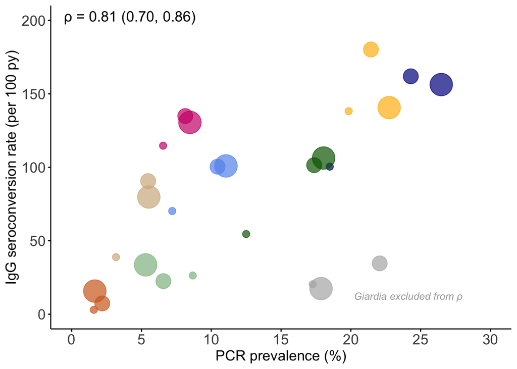

```r
p1 <- d3 %>% ggplot(aes(x = pcr_prevalence*100,
                         y = ir_per_100,
                         color = pathogen)) +
  geom_point(aes(size = n_children), alpha = 0.7) +
  scale_size(
    range = c(3, 10),
    breaks = c(84, 108, 177),
    labels = c("Esmeraldas (n=84)", "Borbón (n=108)", "Rural (n=177)"),
    name = "Community type"
  ) +
  labs(x = "PCR prevalence (%)",
       y = "IgG seroconversion rate (per 100 py)") +
  scale_color_manual(values = my_colors, name = "") +
  scale_x_continuous(breaks = seq(0, 30, by = 5), limits = c(0, 30)) +
  dotplot_theme +
  coord_cartesian(ylim = c(0, 200)) +
  geom_text(
    data = corr_ci_p1_excl,
    aes(x = -Inf, y = Inf, label = paste0("ρ = ", final_rho)),
    inherit.aes = FALSE,
    hjust = -0.1, vjust = 1.5, size = 5, color = "black"
  ) +  annotate("text", x = 28, y = 10, label = "Giardia excluded from ρ",
           hjust = 1, vjust = 0, size = 3.5, color = "darkgrey", fontface = "italic")

p1
```

## C) SCR vs. Seroprevalence

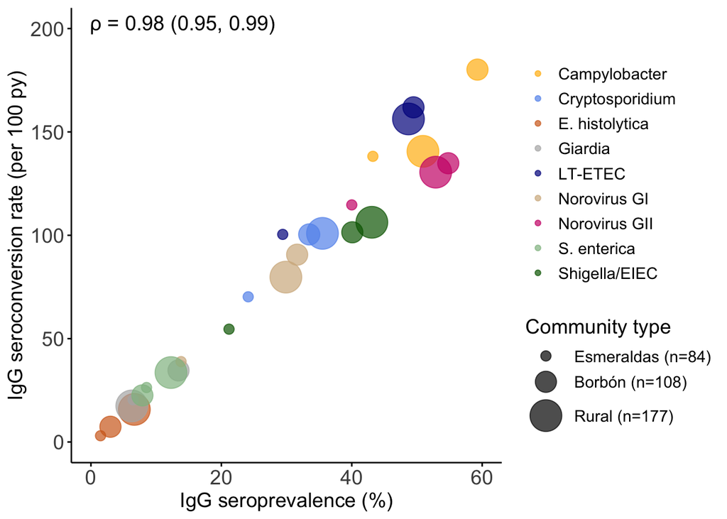

```r
p2 <- d4 %>% ggplot(aes(x = sero_prevalence*100, y = ir_per_100, color = pathogen)) +
  geom_point(aes(size = n_children), alpha = 0.7) +
  labs(x = "IgG seroprevalence (%)",
       y = "IgG seroconversion rate (per 100 py)") +
  scale_color_manual(values = my_colors, name = "") +
  scale_size(
    range = c(3, 10),
    breaks = c(84, 108, 177),
    labels = c("Esmeraldas (n=84)", "Borbón (n=108)", "Rural (n=177)"),
    name = "Community type"
  ) +
  theme(text = element_text(size = 14),
  panel.grid.major = element_blank(),
  panel.grid.minor = element_blank(),
  axis.line = element_line(color = "black"),
  axis.ticks = element_line(color = "black"),
  axis.text.x = element_text(size = 14),
  axis.text.y = element_text(size = 14),
  legend.position = "right",
  panel.background = element_rect(fill = "white"),
  panel.grid = element_line(color = "grey", linewidth = 0.1)) +
  geom_text(
    data = corr_ci_p2,
    aes(x = -Inf, y = Inf, label = paste0("ρ = ", final_rho)),
    inherit.aes = FALSE,
    hjust = -0.1, vjust = 1.5, size = 5, color = "black"
  ) +
  xlim(0, 60) +
  coord_cartesian(ylim = c(0, 200))

p2
```

## D) SCR vs. SRR

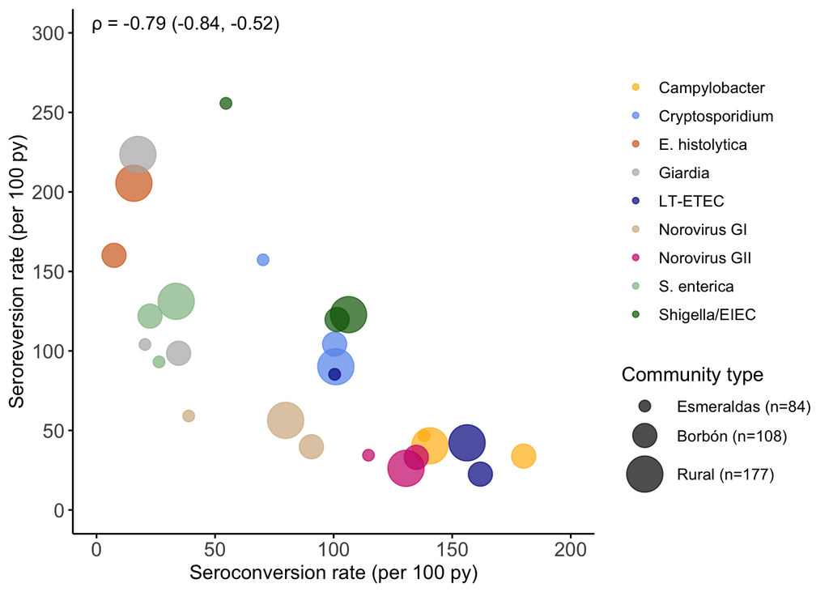

```r
p3 <- d5 %>% ggplot(aes(x = scr_per_100, y = srr_per_100, color = pathogen)) +
  geom_point(aes(size = n_children), alpha = 0.7) +
  labs(x = "Seroconversion rate (per 100 py)",
       y = "Seroreversion rate (per 100 py)") +
  scale_color_manual(values = my_colors, name = "") +
  scale_size(
    range = c(3, 10),
    breaks = c(84, 108, 177),
    labels = c("Esmeraldas (n=84)", "Borbón (n=108)", "Rural (n=177)"),
    name = "Community type"
  ) +
  theme(text = element_text(size = 12),
  panel.grid.major = element_blank(),
  panel.grid.minor = element_blank(),
  axis.line = element_line(color = "black"),
  axis.ticks = element_line(color = "black"),
  axis.text.x = element_text(size = 12),
  axis.text.y = element_text(size = 12),
  legend.position = "right",
  panel.background = element_rect(fill = "white"),
  panel.grid = element_line(color = "grey", linewidth = 0.1)) +
  geom_text(
    data = corr_ci_p3,
    aes(x = -Inf, y = Inf, label = paste0("ρ = ", final_rho)),
    inherit.aes = FALSE,
    hjust = -0.1, vjust = 1.5, size = 4, color = "black"
  ) +
  xlim(0, 200) +
  coord_cartesian(ylim = c(0, 300), clip = "off") +
  scale_y_continuous(limits = c(0, 300), breaks = seq(0, 300, by = 50))

p3
```

```r
## Saved as its own ggplot object -- not folded into the combined figure
## below, so it can be read into a separate R file and composed into a
## supplemental figure there.
saveRDS(p3, here("output/dotplot_scr_vs_srr.rds"))
```

## B) SCR vs. PCR KM cumulative incidence, 24 months

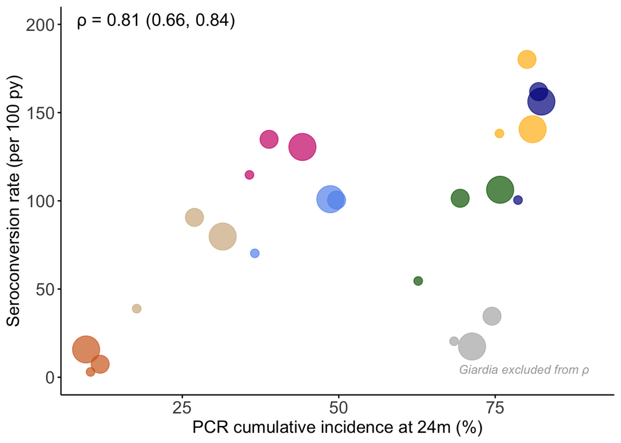

```r
p6 <- d9 %>% ggplot(aes(x = pcr_cum_inc_24*100, y = ir_per_100, color = pathogen)) +
  geom_point(aes(size = n_children), alpha = 0.7) +
  labs(x = "PCR cumulative incidence at 24m (%)",
       y = "Seroconversion rate (per 100 py)") +
  scale_color_manual(values = my_colors, name = "") +
  scale_size(
    range = c(3, 10),
    breaks = c(84, 108, 177),
    labels = c("Esmeraldas (n=84)", "Borbón (n=108)", "Rural (n=177)"),
    name = NULL
  ) +
  dotplot_theme +
  coord_cartesian(ylim = c(0, 200)) +
  geom_text(
    data = corr_ci_f,
    aes(x = -Inf, y = Inf, label = paste0("ρ = ", final_rho)),
    inherit.aes = FALSE,
    hjust = -0.1, vjust = 1.5, size = 5, color = "black"
  ) +
  annotate("text", x = 90, y = 2, label = "Giardia excluded from ρ",
           hjust = 1, vjust = 0, size = 3.5, color = "darkgrey", fontface = "italic")

p6
```